# Unidad 3 - Topic Modeling

Nidia Hernández

###### nidiahernandez@conicet.gov.ar

En esta guía vamos a:

- definir brevemente el *topic modeling* a través de un estudio de caso
- poner en práctica herramientas de modelado de tópicos en un corpus de textos histórico-literarios

## Introducción

El *topic modeling* es un método estadístico de organización de grandes corpus en el que un algoritmo recibe datos no etiquetados para agruparlos según patrones comunes subyacentes. Si bien esta técnica fue concebida para la gestión de colecciones textuales, tiene aplicaciones en diversos campos, tales como la genética de poblaciones y el procesamiento de imágenes por IA.

En el ámbito del procesamiento de textos en particular, el *topic modeling* es utilizado para detectar los tópicos[^1] presentes en una colección textual, los documentos que responden a cada tópico así como las palabras que lo representan. En otras palabras, esta técnica nos permite acceder rápidamente al contenido de un gran dataset de textos y organizar los textos en grupos de acuerdo a su temática.

[figure not shown]

*Figura 1. Detección de tópicos en una matriz de términos por documento. Cada columna corresponde a un documento y cada fila a una palabra; las celdas muestran la frecuencia de una palabra de un documento (más oscura, mayor frecuencia). Fuente: Christoph Carl Kling, via Wikimedia Commons, CC-BY-SA-4.0*

Un buen ejemplo de *topic modeling* aplicado a las humanidades es el trabajo del proyecto [WhatEvery1Says](https://we1s.ucsb.edu/), que se sirve de esta técnica de macroanálisis para estudiar la representación de las disciplinas de humanidades en el discurso público de Estados Unidos a lo largo de 20 años. Gracias al *topic modeling*, este proyecto ha podido explorar 21 colecciones textuales integradas por 83 000 artículos periodísticos, 21 000 artículos de diarios universitarios, 800 000 tweets y 124 000 posts de Reddit y agrupar los textos por temáticas como “la crisis de las humanidades”, “el valor de las humanidades”, “las humanidades y las ciencias en los medios”, “el financiamiento de las humanidades”, entre otros.

[interactive chart not shown]

*Figura 2. Detección de tópicos del proyecto [WhatEvery1Says](https://we1s.ucsb.edu/) para la colección de artículos de [medios de los EEUU entre 1989-2019](http://harbor.english.ucsb.edu:10002/collections/20190620_2238_us-humanities-all-no-reddit/). Hacer click sobre los tópicos para abrir una nube de palabras interactiva.*

La visualización interactiva de arriba representa 25 tópicos detectados en una colección de más de 83 mil artículos periodísticos de grandes medios de Estados Unidos (New York Times, Washington Post, Los Angeles Times, Chicago Tribune, entre otros). Los círculos más grandes representan tópicos con mayor peso. En las nubes de palabras asociadas, podemos ver las principales palabras que componen cada tópico y, si clickeamos en el círculo turquesa de abajo a la derecha, podremos acceder a un gráfico de los principales periódicos en los que se publicaron los artículos analizados así como los títulos de los artículos más representativos del tópico.

Si clickeamos en el tópico 17, por ejemplo, podremos ver palabras relacionadas con eventos universitarios (estudiantes, campus, conferencia, evento, discusión, charla, etc.) y, si consultamos las fuentes de los artículos, encontraremos periódicos universitarios (The Stanford Daily, Campus Carrier y publicaciones de otras universidades). Al acceder a los principales documentos de este tópico, econtraremos, efectivamente, títulos como “College of DuPage Hosts ‘What is Gender?’ Panel Discussion Nov. 8”, “Race: A Campus Dialogue” o “Festival of Books and Arts at UTPA”. Entre los demás tópicos, podremos encontrar temas relacionados de manera más directa (escritura académica, tópico 4) o más indirecta (política internacional, tópico 16).

Para comprender mejor el funcionamiento de este método estadístico de lectura distante, comenzaremos por aplicarlo a un caso donde ya conocemos la respuesta de antemano: buscaremos agrupar temáticamente un corpus de tres textos[^2] (para reproducir los pasos de la guía, descargar el corpus vía [campus](https://campusvirtual.uces.edu.ar/mod/folder/view.php?id=333749)) y veremos si el algoritmo de *topic modeling* es capaz de distinguir correctamente tres grupos. Utilizaremos los txt correspondientes a [*Relación de las cosas sucedidas en el Río de la Plata*](http://hdlab.space/Relacion-de-las-cosas-sucedidas/) de Pero Hernández, [*Relación de un viaje al Río de la Plata*](http://hdlab.space/Relacion-de-un-viaje/) de Acarette du Biscay y [*La Argentina Manuscrita*](http://hdlab.space/La-Argentina-Manuscrita/) de Ruy Díaz de Guzmán, relatos histórico-literarios sobre la conquista y colonización del Río de la Plata. Estos textos se encuentran disponibles en edición digital y forman parte de la biblioteca digital de HDCAICYT LAB http://hdlab.space/biblioteca-digital/.

## Implementación

### Preparación de los datos de entrada

Existen diversos paquetes y algoritmos para realizar *topic modeling* en R, tales como mallet, lda y topicmodels. En esta práctica vamos a servirnos de este último.

Para comenzar, vamos a cargar varios paquetes necesarios para la experimentación. Algunos de ellos (`topicmodels`, `tm` y `scales`) no fueron utilizados antes en nuestras prácticas, por lo que vas a tener que instalarlos con `install.packages()`. Si la instalación de `topicmodels` emite un mensaje de error, abrí una terminal y ejecutá `sudo apt install libgsl-dev` en Linux o `brew install gsl` en MacOS.

```r
library(tidyverse)
library(tidytext)
library(tm)
library(topicmodels)
library(scales)
```

A continuación, cargamos el corpus en una tibble de dos columnas, **texto** y **documento**, y asignamos a la primera el contenido textual de cada archivo del corpus y a la segunda el nombre de cada archivo. Luego tokenizamos, limpiamos el corpus (filtrando stopwords, eliminando números y palabras de un solo caracter) y calculamos las ocurrencias de cada palabra en cada documento:

```r
path_archivos <-
  list.files("corpus-tp", pattern = "\\.txt$", full.names = TRUE) # Modificar de acuerdo al nombre de la carpeta donde se encuentra nuestro corpus

coleccion <- tibble(texto = character(),
                    documento = character())

for (path in path_archivos) {
  lineas <- read_lines(path)
  temporal <- tibble(texto = lineas,
                     documento = basename(path))
  coleccion <- bind_rows(coleccion, temporal)
}

stopwords_es <-
  get_stopwords("spa") %>%
  rename(palabra = word)

coleccion <-
  coleccion %>%
  unnest_tokens(palabra, texto) %>%
  anti_join(stopwords_es) %>%
  filter(!str_detect(palabra, "[0-9]+")) %>% # elimina números
  filter(nchar(palabra) > 1) %>% # elimina palabras como "ó", "á", "é"
  count(documento, palabra, sort = TRUE) # cuenta ocurrencias de cada palabra en su documento
```

Es muy importante señalar que en esta etapa de preparación de datos de entrada o preprocesamiento, podemos combinar tratamientos vistos en las unidades anteriores –como generar ngrams o filtrar por clase de palabra– o técnicas de NLP más sofisticadas –como [identificación de Named Entities](https://es.wikipedia.org/wiki/Reconocimiento_de_entidades_nombradas)– que pueden beneficiar enormemente la calidad de los resultados para la interpretación humana.

La preparación mínima requerida para esta experiencia de *topic modeling* consiste en un dataframe con el nombre de cada documento, las palabras de cada documento y la frecuencia de cada palabra en cada documento:

```r
coleccion
```

| documento | palabra | n |
| --- | --- | --- |
| DiazDeGuzman_ArgManus.txt | indios | 330 |
| DiazDeGuzman_ArgManus.txt | aquella | 288 |
| DiazDeGuzman_ArgManus.txt | río | 286 |
| DiazDeGuzman_ArgManus.txt | tierra | 256 |
| DiazDeGuzman_ArgManus.txt | capitán | 231 |
| DiazDeGuzman_ArgManus.txt | gente | 228 |
| DiazDeGuzman_ArgManus.txt | parte | 158 |
| DiazDeGuzman_ArgManus.txt | provincia | 158 |
| DiazDeGuzman_ArgManus.txt | así | 143 |
| DiazDeGuzman_ArgManus.txt | gran | 142 |

[output cut: 9990 more lines]

El paquete `topicmodels` requiere los datos de entrada en un formato particular conocido como `DocumentTermMatrix` (Matrices de Términos por Documento; en la Unidad de Introducción al Análisis Textual, vimos ejemplos de este tipo de matrices en las [tablas de tipos de frecuencias](http://hdlab.space/Estilometria-con-R/unidad2_analisis-textual.html#frecuencia-absoluta-frecuencia-relativa-y-tf.idf)). Podemos transformar nuestro dataframe `coleccion` en un objeto `DocumentTermMatrix` gracias a la función `cast_dtm()`.

```r
coleccion_dtm <-
  coleccion %>%
  cast_dtm(documento, palabra, n)
```

Ahora que los datos están en el formato adecuado, podemos pasar a la etapa de aprendizaje automático.

### Entrenamiento con LDA

Una vez que transformamos el corpus al formato requerido por `topicmodels`, podemos someter los datos al algoritmo de extracción de tópicos. En esta práctica veremos cómo implementar LDA (siglas de *Latent Dirichlet Allocation*), uno de los métodos más populares de *topic modeling*, desarrollado por David Blei en 2012[^3]. Obtendremos como resultado modelos de tópicos (*topic models*). La cantidad de tópicos en un modelo varía en función del corpus, sin embargo, en este ejercicio ya sabemos que queremos encontrar 3 tópicos (uno por cada texto de nuestro corpus), de manera que en la función de entrenamiento fijaremos `k = 3`. En una experiencia real de *topic modeling* es necesario probar diferentes valores de k y evaluar cuál arroja resultados más coherentes[^4].

En primer lugar, creamos el modelo de tres tópicos sobre el corpus bajo análisis (este paso será breve, pero en un corpus más grande y/o con un valor más elevado de k, el entrenamiento puede tomar bastante tiempo):

```r
coleccion_lda <- LDA(coleccion_dtm, k = 3, control = list(seed = 42))
coleccion_lda
```

```
## A LDA_VEM topic model with 3 topics.
```

La generación de modelos con LDA involucra muchos procesos aleatorios[^5], por eso, si queremos poder reproducir y comparar resultados generados por este algoritmo, debemos “plantar una semilla” que permita controlar la variación; para eso establecemos el parámetro `control = list(seed = 42)`.

El resto del análisis involucra explorar e interpretar los tópicos resultantes.

## Análisis de resultados

### Palabras en cada tópico

Veamos las primeras diez palabras más representativas de cada uno de los tres tópicos generados:

```r
terms(coleccion_lda, 10) %>% as_tibble
```

| Topic 1 | Topic 2 | Topic 3 |
| --- | --- | --- |
| indios | gobernador | buenos |
| aquella | dicho | aires |
| río | domingo | cuales |
| tierra | irala | plata |
| capitán | indios | río |
| gente | tierra | españa |
| parte | juan | allí |
| provincia | oficiales | después |
| así | fué | tan |
| gran | puerto | gran |

En esta técnica, cada tópico es una colección de palabras con “pesos” asociados. Las palabras que mejor definen al tópico (las asociadas con mayor probabilidad al tópico) aparecen primero en la lista. Nada impide que tópicos diferentes compartan palabras, pero la combinación de muchas palabras y probabilidades diferencia a los tópicos entre sí.

Ahora que ya conocemos los datos de salida de un modelado LDA, veremos cómo usarlos para generar gráficos. El paquete `tidytext` permite extraer las probabilidades por palabra dentro de cada tópico, a las que llama “betas”. Exploremos, por ejemplo, las palabras de mayor peso en el tópico 2:

```r
topicos_coleccion <-
  tidy(coleccion_lda, matrix = "beta") %>% # Esta línea puede requerir instalar el paquete reshape2
  arrange(topic, desc(beta))

topicos_coleccion %>%
  filter(topic == 2)
```

| topic | term | beta |
| --- | --- | --- |
| 2 | gobernador | 2.061159e-02 |
| 2 | dicho | 1.334685e-02 |
| 2 | domingo | 1.317790e-02 |
| 2 | irala | 1.317790e-02 |
| 2 | indios | 7.940530e-03 |
| 2 | tierra | 7.940530e-03 |
| 2 | juan | 7.771583e-03 |
| 2 | oficiales | 7.433688e-03 |
| 2 | fué | 7.095793e-03 |
| 2 | puerto | 6.926846e-03 |

[output cut: 8802 more lines]

Los valores absolutos de probabilidad no importan tanto como sus relaciones. Usualmente, son números muy pequeños[^6] que provienen de alguna transformación de la frecuencias de la palabra en el documento. En este caso, no nos importa que `gobernador` tenga un valor de 0.02, sino que es el mayor valor observado para este tópico o que es mayor que el valor de `oficiales`.

Vamos a graficar las primeras diez palabras que definen a cada tópico con sus pesos asignados.

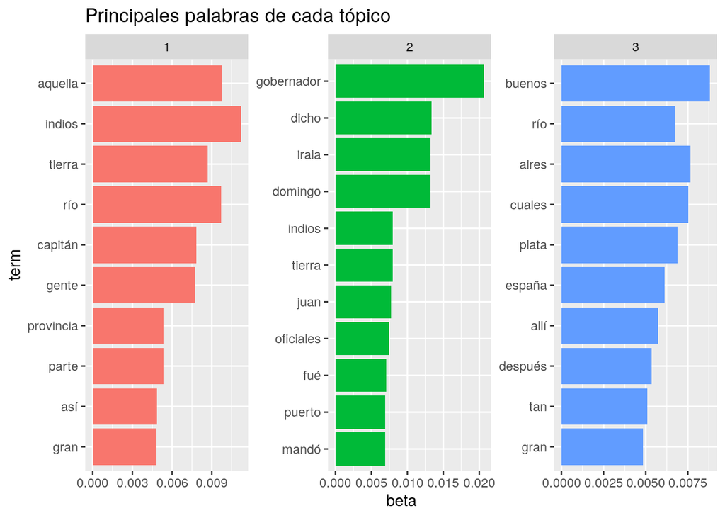

```r
top_terms <- topicos_coleccion %>%
  group_by(topic) %>%
  top_n(10, beta) %>%
  ungroup() %>%
  arrange(topic, -beta)

top_terms %>%
  mutate(term = reorder(term, beta)) %>%
  ggplot(aes(term, beta, fill = factor(topic))) +
  geom_col(show.legend = FALSE) +
  facet_wrap(vars(topic), scales = "free") +
  coord_flip() +
  ggtitle("Principales palabras de cada tópico")
```

## Tópicos en cada documento

Como señalamos más arriba, nuestro conocimiento previo de los textos nos permite inferir rápidamente que el tópico 2 tiene una fuerte asociación al texto de Pero Hernández. Podemos confirmar esto con el valor de “gamma” que la técnica calcula para cada tópico y documento. En el caso bajo análisis, los tres tópicos encontrados distinguen fuertemente a los tres textos, como podemos ver en los valores de gamma redondeados:

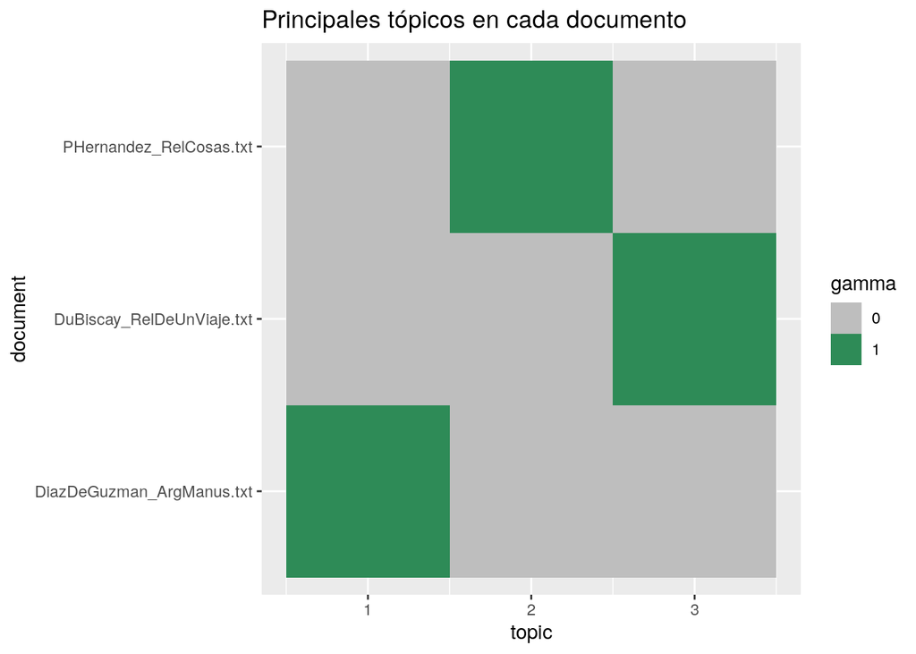

```r
coleccion_gamma <- tidy(coleccion_lda, matrix = "gamma")

coleccion_gamma %>%
  mutate(gamma = factor(round(gamma))) %>%
  ggplot() +
  aes(x = topic, y = document, fill = gamma) +
  geom_tile() +
  scale_fill_manual(values = c("Grey", "SeaGreen")) +
  ggtitle("Principales tópicos en cada documento")
```

Los resultados son, en este caso, categóricos: un texto pertenece a un tópico (color verde) o no pertenece a un tópico (color gris). En experiencias de modelado real, los documentos pueden asociarse a más de un tópico (un texto puede tratar acerca de la fundación de una ciudad **y** del enfrentamiento entre dos personajes). Esta ambigüedad sería representada en el gráfico por un gradiente de color, como en la animación presentada al inicio de la guía.

## Visualización interactiva de tópicos

La complejidad de los resultados del *topic modeling* habilita visualizaciones más dinámicas que las que realizamos hasta el momento con ggplot. Existe una amplia variedad de visualizaciones interactivas, que pueden combinar desde burbujas de tópicos hasta nubes de palabras, lollypop charts y/o diagramas de flujo, entre otras posiblidades (ver [video](https://vimeo.com/437987253) de [TopicBubbles](https://github.com/sihwapark/topic-bubbles) de Sihwa Park o la [demo online](http://agoldst.github.io/dfr-browser/demo/) de [dfr-browser](http://agoldst.github.io/dfr-browser/) de Andrew Goldstone).

Aquí veremos cómo generar un una visualización interactiva con LDAvis una herramienta creada por Carson Sievert y Kenneth E. Shirley que combina un gráfico de barras volteado con representación de distancias de tópicos en coordenadas cartesianas. Comenzamos por cargar la librería `LDAvis` y sus dependencias:

```r
library(tsne)
library(LDAvis)
```

Adaptamos nuestro modelo de tópicos y nuestra matriz de documentos a los formatos requeridos por el paquete:

```r
terminos_y_topicos <- posterior(coleccion_lda)
coleccion_dtm <- as.matrix(coleccion_dtm)
```

Y generamos la visualización con el siguiente código:

```r
svd_tsne <- function(x) tsne(svd(x)$u)
json <- createJSON(
  phi = terminos_y_topicos$terms,
  theta = terminos_y_topicos$topics,
  doc.length = rowSums(coleccion_dtm),
  vocab = colnames(coleccion_dtm),
  term.frequency = colSums(coleccion_dtm),
  mds.method = svd_tsne,
  plot.opts = list(xlab="", ylab="")
)
serVis(json, out.dir = "LDAvis") # Guarda el resultado en el directorio "LDAvis"
```

El resultado quedará guardado como un html en el directorio indicado en `out.dir`.

Deslizá el cursor sobre los círculos y usá los controles de la parte superior para modificar los gráficos:

[interactive chart not shown]

El gráfico de barras de la derecha indica la frecuencia de una palabra en la colección (en azul) y en cada tópico (en rojo). En las coordenadas cartesianas situadas a la izquierda, se representa la distancia entre los tópicos. En el caso analizado, los tópicos son bien ortogonales pero en el caso de haber similitudes entre los tópicos, los círculos aparecerían superpuestos. El tamaño de los círculos indica, por otra parte, el peso del tópico en la colección; así, el tópico asociado al documento más extenso, *La Argentina Manuscrita* (tópico 1), es más importante. La relación entre los tópicos y las palabras que los conforman está ilustrada de manera interactiva: al deslizar el cursor sobre el círculo de cada tópico, el gráfico de barras cambia para mostrar la lista de palabras de ese tópico.

Esta ha sido una pequeña introducción a la técnica realizada con un minicorpus de tres textos donde ya sabíamos la respuesta. El verdadero interés del *topic modeling* se vuelve evidente al aplicarlo a colecciones más amplias para **descubrir** los tópicos. Te invitamos a experimentar con la práctica que se encuentra al final de la guía.

## Bibliografía

- Maier, D., Waldherr, A., Miltner, P., Wiedemann, G., Niekler, A., Keinert, A., Pfetsch, B., Heyer, G., Reber, U., Häussler, T., Schmid-Petri, H., & Adam, S. (2018). Applying LDA Topic Modeling in Communication Research: Toward a Valid and Reliable Methodology. Communication Methods and Measures, 12(2–3), 93–118. https://doi.org/10.1080/19312458.2018.1430754
- Mohr, J. W., & Bogdanov, P. (2013). Introduction—Topic models: What they are and why they matter. Poetics, 41(6), 545–569. https://doi.org/10.1016/j.poetic.2013.10.001
- Silge, J., & Robinson, D. (2017). Topic modeling. En *Text mining with R: A tidy approach*. O’Reilly Media. Disponible en línea: https://www.tidytextmining.com/topicmodeling.html
- Underwood, T. (2012) Topic modeling made just simple enough. The Stone and the Shell. (2012, abril 7). https://tedunderwood.com/2012/04/07/topic-modeling-made-just-simple-enough/

## Práctica

- Leer los txt de los discursos presidenciales utilizados en las prácticas anteriores (u otro corpus de tu interés).
- Tokenizarlos, limpiarlos y guardarlos en un dataframe.
- Transformar el dataframe en una DTM (DocumentTermMatrix).
- Extraer los tópicos de los discursos presidenciales transformados en DTM con LDA. Probar distintos valores de k hasta encontrar tópicos relevantes. Modificar la limpieza de ser necesario.
- Graficar las primeras 7 palabras de cada tópico con ggplot
- Compartir y comentar los resultados en el [foro](https://campusvirtual.uces.edu.ar/mod/forum/view.php?id=333750).
[^1]: Algunas aclaraciones sobre la terminología típica asociada a esta técnica: utilizamos el término *colección* para denominar al conjunto de textos con el que vamos a trabajar y *documento* para referirnos a cada uno de los textos. Los resultados a obtener son *tópicos* o temas.
[^2]: Aplicamos *topic modeling* en un corpus reducido únicamente a fines pedagógicos. El interés real de esta técnica radica en la exploración de colecciones de un número elevado de textos.
[^3]: Blei, D. M. (2012). Probabilistic topic models. *Communications of the ACM*, 55(4), 77–84. https://doi.org/10.1145/2133806.2133826
[^4]: Para un ejemplo de evaluación de *topic modeling* con distintos valores de k, consultar https://github.com/nidiah/Topic-modeling-gestion-datos/blob/main/experiencias_informes.ipynb (en Python)
[^5]: Para una introducción a los fundamentos matemáticos de LDA, consultar https://www.youtube.com/watch?v=T05t-SqKArY
[^6]: Para anular la notación científica, podés agregar `options("scipen" = 100, "digits" = 4)` a tu script.